# SingleR cell type exploration - Combining references

Results for SCPCL000296.

This notebook is focused on a preliminary analysis of using SingleR with combining references. I mostly followed the setup outlined in the [SingleR book section on combining multiple references with harmonizing labels](http://bioconductor.org/books/release/SingleRBook/using-multiple-references.html#using-harmonized-labels). To do this, I created a list of all references and then grabbed the `label.ont` from all references and provided both of those as input to `SingleR::SingleR()` to annotate a single library.

## Set Up

```r
suppressPackageStartupMessages({
  library(SingleCellExperiment)
  library(ggplot2)
})
theme_set(theme_bw())
```

```r
# make local data directory if it doesn't exist
fs::dir_create(params$local_data_dir)
fs::dir_create(params$local_ref_dir)
```

```r
# Define list of reference files that we will use for combined analysis
refs <- c("BlueprintEncodeData",
          "HumanPrimaryCellAtlasData",
          "DatabaseImmuneCellExpressionData",
          "MonacoImmuneData")
ref_files <- glue::glue("celldex-{refs}.rds")
local_ref_paths <- file.path(params$local_ref_dir, ref_files) |>
  purrr::set_names(refs)

# if missing the reference files, grab them from S3
if(!all(file.exists(local_ref_paths))){
  # sync reference files
  aws_includes <- paste("--include '", ref_files, "'", sep = '', collapse = ' ')
  sync_call <- paste('aws s3 cp', params$s3_ref_dir, params$local_ref_dir,
                     '--exclude "*"', aws_includes,'--recursive', sep = " ")
  system(sync_call, ignore.stdout = TRUE)
}

# read all ref files in as a single list
celldex_refs <- purrr::map(local_ref_paths, readr::read_rds)
```

```r
# build path to annotated sce file
annotated_sce_file <- glue::glue("{params$library_id}_annotated.rds")
local_annotated_sce_path <- file.path(params$local_data_dir,
                                      params$sample_id,
                                      annotated_sce_file)

# if missing the annotated sce files, grab them from S3
if(!all(file.exists(local_annotated_sce_path))){
  # sync annotated SCE files
  aws_includes <- glue::glue('--include "*/{annotated_sce_file}"')

  sync_call <- glue::glue('aws s3 sync {params$s3_data_dir} {params$local_data_dir} --exclude "*" {aws_includes}')
  system(sync_call, ignore.stdout = TRUE)
}

# read in all annotated sce
annotated_sce <- readr::read_rds(local_annotated_sce_path)
```

## SingleR with combined reference

Before providing the list of references and labels, first subset them so that they contain the same set of genes.

```r
# identify shared genes among all references
shared_ref_genes <- celldex_refs |>
    purrr::map(rownames) |>
    purrr::reduce(intersect)

# grab cell label names corresponding to cell ontology ids
cl_ont <- ontoProc::getCellOnto()

# create list of refs with shared genes only and replace ont labels with cell type names
celldex_refs_shared <- celldex_refs |>
  purrr::map(\(ref){
             ref <- ref[shared_ref_genes ,]
             ref$cell_label_ont <- cl_ont$name[ref$label.ont]
             return(ref)
             })
```

```r
# create list of labels
cl_ont_labels <- celldex_refs_shared |>
  purrr::map(\(ref) ref$cell_label_ont)
```

```r
# perform SingleR using combined refs and labels
combined_result <- SingleR::SingleR(test = annotated_sce,
                                    ref = celldex_refs_shared,
                                    labels = cl_ont_labels)
```

## Evaluate combined reference annotations

```r
result_df <- combined_result |>
  as.data.frame() |>
  # recode the reference assigned
  dplyr::mutate(reference = forcats::fct_recode(as.factor(reference),
    "BlueprintEncodeData" = "1",
    "HumanPrimaryCellAtlasData" = "2",
    "DatabaseImmuneCellExpressionData" = "3",
    "MonacoImmuneData" = "4"
   ))
```

The first thing I looked at was the labels that end up getting assigned and which reference was used to assign those labels.

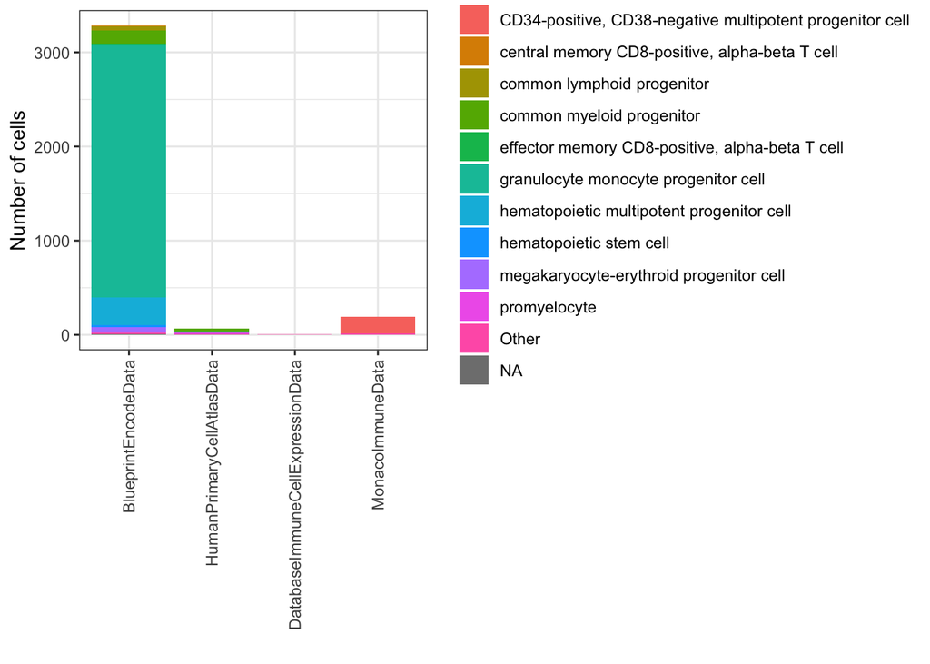

```r
# only pull out the top 10 labels
top_label_counts_df <- result_df |>
  dplyr::mutate(top_labels = forcats::fct_lump_n(pruned.labels, 10)) |>
  dplyr::count(top_labels, reference)

# same barchart but with just the top 10 labels
ggplot(top_label_counts_df, aes(x = reference, fill = top_labels, y = n)) +
  geom_bar(position = "stack", stat = "identity") +
  labs(x = "",
       y = "Number of cells",
       label = "Cell type") +
  guides(x = guide_axis(angle = 90))
```

It looks like most of the labels are coming from monocyte progenitors in BlueprintEncodeData reference with a few cells being assigned to other labels present in the other datasets.

Below, I looked at how the labels looked when using all references vs. single references. When running SingleR with multiple references, first DE genes are identified within each reference and labels assigned within each reference and then statistics are merged across references (I’m still slightly unclear on exactly what that means).

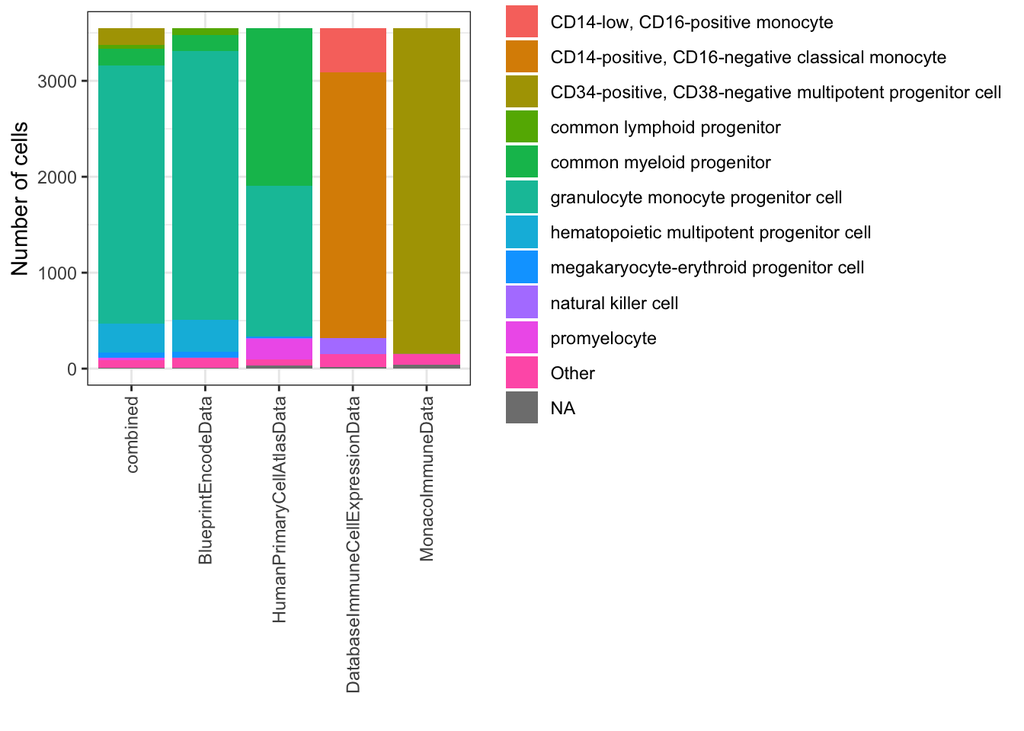

```r
# get all the labels from combined and each individual reference
all_results <- result_df |>
  dplyr::select(ends_with("pruned.labels")) |>
  tidyr::pivot_longer(cols = everything(),
                      values_to = "label.ont",
                      names_to = "reference") |>
  # rename final assigned labels as combined and remove some extra strings
  dplyr::mutate(reference = ifelse(reference == "pruned.labels", "combined", reference),
                reference = stringr::str_remove_all(reference, "orig.results.|.pruned.labels")) |>
  # grab top 10 and relevel for ordering |>
  dplyr::mutate(top_labels = forcats::fct_lump_n(label.ont, 10),
                reference = factor(reference,
                                   levels = c("combined",
                                              "BlueprintEncodeData",
                                              "HumanPrimaryCellAtlasData",
                                              "DatabaseImmuneCellExpressionData",
                                              "MonacoImmuneData"))) |>
  dplyr::count(top_labels, reference)

# create a barchart to look at assignments between combined vs. single refs
ggplot(all_results, aes(x = reference, fill = top_labels, y = n)) +
  geom_bar(position = "stack", stat = "identity")  +
  labs(x = "",
       y = "Number of cells",
       label = "Cell type") +
  guides(x = guide_axis(angle = 90))
```

It looks like the combined references look the most similar to the BlueprintEncodeData. However, if we used individual references we see that the other references assign cells as CD34+ progenitors or monocytes. In the combined reference we also see a small portion of the cells are annotated as CD34+ progenitors, which would not have been the case if we only used BlueprintEncodeData.

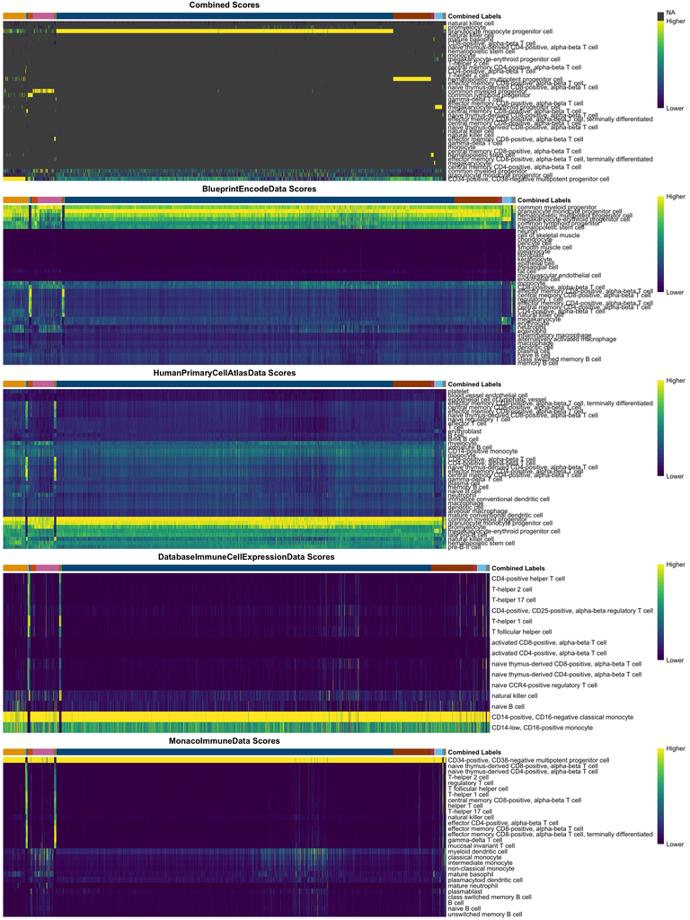

```r
# make some heatmaps because why not
SingleR::plotScoreHeatmap(combined_result,
                          grid.vars = list(ncol = 1),
                          annotation_legend = FALSE,
                          treeheight_row = 0)
```